# Dam impacts on food webs predicted from species presence

D12 relates the observed food webs of each visit to the number of large dams between the site and the sea. The webs are reconstructed from the fish caught, so they are noisy: most of the variation of trophic length is from one visit to the next at the same site. Here, food webs are instead predicted from models of the presence of each species, in three steps:

1. Fit a presence model for each species, with the dams and the position along the river.
2. Check that the webs generated from these models reproduce the observed ones.
3. Generate webs with and without the dams, and measure the dam impact on their structure.

The uncertainty of the presence models is carried through to the webs and the dam impacts by working with joint posterior draws. Food webs are built at the species level throughout.

## Summary

- presence models of 48 species (99.7% of the fish caught), with the dams and the position along the river, generate food webs that reproduce the observed ones (calibrated, correlation 0.7-0.9 per visit)
- the species lost with dams are enough to shorten food chains slightly and raise diet overlap slightly, at species level
- the dam effects on the observed webs match those on the generated webs: dams change food web structure through which species are present, with no sign of a further effect
- the dam effect on trophic length is larger at the species level than with size classes, because it comes from the change of top predator (eel, pike, salmon replaced by brown trout), but it is uncertain
- the number of dams fits as well as any weighting of the dams by rank
- a few dams, first from the sea on large rivers, would bring back most of the species if removed; predicted over the whole network, a dam matters through the river length it cuts off and its rank from the sea
- this ranking is close to the diadromous connectivity index (river length reachable from the sea) with a dam passability of about 0.75

## To do

- Predictive scores of the generated webs across dam weightings (needs the presence models refitted for each weighting)

## Setup

```r
library(renv)
renv::load()
library(targets)
library(here)
tar_config_set(
  store = here::here("_targets")
)
library(ggplot2)
library(dplyr)
devtools::load_all()
nice_theme()
```

## Visits

All visits of river (ASPE) sites with fish records, as in D12 (target `dam_visit`): dams are the large dams and weirs (ROE, drop height $\geq$ 5 m) between the site and the sea, placed on the AMOBIO network after a manual review (see D12).

```r
visit <- tar_read(dam_visit)
settings <- tar_read(dam_web_settings)
c(
  visits = nrow(visit), sites = n_distinct(visit$sandre_code),
  catchments = n_distinct(visit$catchment), with_dam = mean(visit$dams > 0)
)
```

```
      visits        sites   catchments     with_dam
5929.0000000 1685.0000000   91.0000000    0.3444088
```

## Presence models

One model per species found at >= 30 sites (target `dam_presence_sample`). For visit $i$ at site $s$, in year $t$ and catchment $c$, the presence $Y_i$ of the species is

$$\begin{aligned}
Y_i &\sim \mathrm{Bernoulli}(p_i), \\
\mathrm{logit}\, p_i &= \beta_0 + \beta_D \log(1 + D_i) + \beta_W W_i
+ \beta_H H_i + \beta_{H^2} H_i^2 + \beta_M M_i \\
&\quad + \alpha_{\mathrm{district}(i)} + \gamma_{\mathrm{protocol}(i)}
+ \beta_A \log A_i + u_s + v_t + w_c
\end{aligned}$$

with $D_i$ the number of large dams and weirs between the site and the sea, $W_i$ the log river width, $H_i$ the log altitude and $M_i$ the log distance to the mouth (centred; see D12 for the choice of these controls), $A_i$ the fished surface, and iid random effects of the site ($u_s$), the year ($v_t$) and the catchment ($w_c$). From each model, 200 joint draws of the posterior are kept: the linear predictor of each visit (which includes the random effects) and the dam effect $\beta_D$, from the same draws.

```r
presence <- tar_read(river_presence)
presence_species <- tar_read(dam_presence_species)
c(
  species = length(presence_species),
  share_of_occurrences = mean(
    presence$species_valid[presence$operation_id %in% visit$operation_id] %in% presence_species
  )
)
```

```
             species share_of_occurrences
          48.0000000            0.9974673
```

Dam effect $\beta_D$ per species (posterior mean and 95% credible interval).

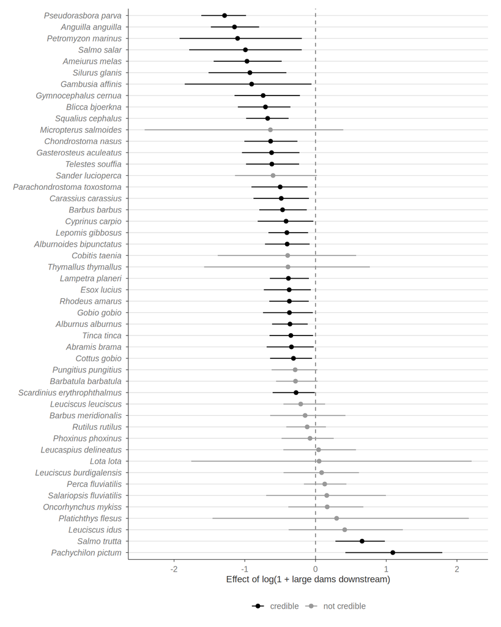

```r
tar_read(dam_presence_effect) |>
  mutate(
    species = reorder(species, -mean),
    credible = if_else(upper < 0 | lower > 0, "credible", "not credible")
  ) |>
  ggplot(aes(mean, species, color = credible)) +
  geom_vline(xintercept = 0, linetype = "dashed", color = "grey50") +
  geom_pointrange(aes(xmin = lower, xmax = upper), size = 0.3) +
  scale_color_manual(values = c(credible = "black", `not credible` = "grey60")) +
  labs(x = "Effect of log(1 + large dams downstream)", y = NULL, color = NULL) +
  theme(axis.text.y = element_text(face = "italic"))
```

**Results:** the 48 modelled species cover almost all the fish caught. More than half of them are credibly less frequent with more dams downstream: the migratory species (sea lamprey, eel, salmon) and species of large lowland rivers, native or not. As in D12, brown trout is more frequent with dams; so is the Albanian roach (*Pachychilon pictum*), an introduced species.

## Species-level food webs

The food web of a set of species is cut out of the species-level metaweb (target `species_metaweb`): two species are linked if any size class of the predator eats any size class of the prey. The 10 resources (detritus, biofilm, macrophytes, phytoplankton, zooplankton, worms, molluscs, crustaceans, insects, echinoderms) are in every web. Four measures:

- fish richness $S$, the number of fish species;
- trophic length $L$, the maximum prey-averaged trophic level;
- piscivore presence $P$, whether a fish species eats another fish;
- diet overlap $O$, the mean Jaccard similarity of the prey of pairs of fish species.

The observed species-level webs are built from the species caught, keeping only the modelled species (target `dam_web_observed`), so that observed and generated webs are comparable. They differ from the size-class webs of D11 and D12, which only keep the size classes caught.

```r
observed <- tar_read(dam_web_observed)
size_class <- tar_read(foodweb_structure) |>
  filter(survey == "river") |>
  distinct(operation_id, .keep_all = TRUE) |>
  mutate(operation_id = as.character(operation_id)) |>
  select(operation_id, trophic_length, fish_diet_overlap)
observed |>
  mutate(operation_id = as.character(operation_id)) |>
  inner_join(size_class, by = "operation_id", suffix = c("", "_size_class")) |>
  summarise(
    trophic_length = cor(trophic_length, trophic_length_size_class, use = "complete"),
    fish_diet_overlap = cor(fish_diet_overlap, fish_diet_overlap_size_class, use = "complete")
  )
```

```
# A tibble: 1 × 2
  trophic_length fish_diet_overlap
           <dbl>             <dbl>
1          0.752             0.721
```

## Do the presence models reproduce the observed webs?

For each visit and posterior draw, the presence of each species is drawn from its presence probability, the web of the species present is built, and its structure measured (target `dam_web_simulated`). Each visit thus has 200 generated webs, whose spread carries the uncertainty of the presence models and the chance of which species are caught.

```r
simulated <- tar_read(dam_web_simulated)
metric_label <- c(
  richness = "S: fish richness", trophic_length = "L: trophic length",
  piscivore = "P: piscivore present", fish_diet_overlap = "O: diet overlap (fish)"
)
generated <- lapply(names(metric_label), function(m) {
  web <- simulated$web[, , m, "dams"]
  tibble(
    operation_id = simulated$operation_id, metric = m,
    mean = rowMeans(web, na.rm = TRUE),
    q05 = apply(web, 1, quantile, 0.05, na.rm = TRUE),
    q25 = apply(web, 1, quantile, 0.25, na.rm = TRUE),
    q75 = apply(web, 1, quantile, 0.75, na.rm = TRUE),
    q95 = apply(web, 1, quantile, 0.95, na.rm = TRUE)
  )
}) |>
  bind_rows() |>
  inner_join(
    observed |> tidyr::pivot_longer(-operation_id, names_to = "metric", values_to = "observed"),
    by = c("operation_id", "metric")
  ) |>
  filter(!is.na(observed), !is.na(mean)) |>
  left_join(distinct(visit, operation_id, sandre_code), by = "operation_id")
```

Observed against generated structure (mean of the generated webs), one point per visit; dashed line: 1:1.

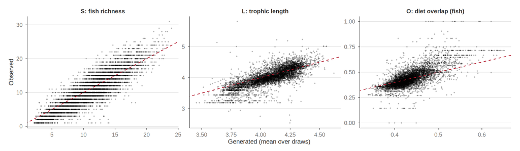

```r
generated |>
  filter(metric != "piscivore") |>
  mutate(metric = factor(metric, names(metric_label), metric_label)) |>
  ggplot(aes(mean, observed)) +
  geom_point(size = 0.4, alpha = 0.2) +
  geom_abline(linetype = "dashed", color = "#B2182B") +
  facet_wrap(~metric, nrow = 1, scales = "free") +
  labs(x = "Generated (mean over draws)", y = "Observed")
```

Agreement between observed and generated structure: correlation per visit and per site (means over the visits of a site), and share of the visits whose observed value falls within the central 50% and 90% of the generated webs (expected: 0.5 and 0.9 if the generated webs are calibrated).

```r
generated |>
  summarise(
    correlation_visit = cor(mean, observed),
    coverage_50 = mean(observed >= q25 & observed <= q75),
    coverage_90 = mean(observed >= q05 & observed <= q95),
    .by = metric
  ) |>
  left_join(
    generated |>
      summarise(mean = mean(mean), observed = mean(observed), .by = c(metric, sandre_code)) |>
      summarise(correlation_site = cor(mean, observed), .by = metric),
    by = "metric"
  ) |>
  mutate(across(where(is.numeric), \(x) round(x, 2)))
```

```
# A tibble: 4 × 5
  metric            correlation_visit coverage_50 coverage_90 correlation_site
  <chr>                         <dbl>       <dbl>       <dbl>            <dbl>
1 richness                       0.88        0.54        0.88             0.93
2 trophic_length                 0.77        0.55        0.94             0.85
3 piscivore                      0.55        0.99        1                0.72
4 fish_diet_overlap              0.71        0.56        0.93             0.8
```

The species are drawn independently of each other, given their presence probabilities. Co-occurrence of each pair of species: observed number of visits where both are caught against the number expected from the presence probabilities (pairs expected at >= 20 visits).

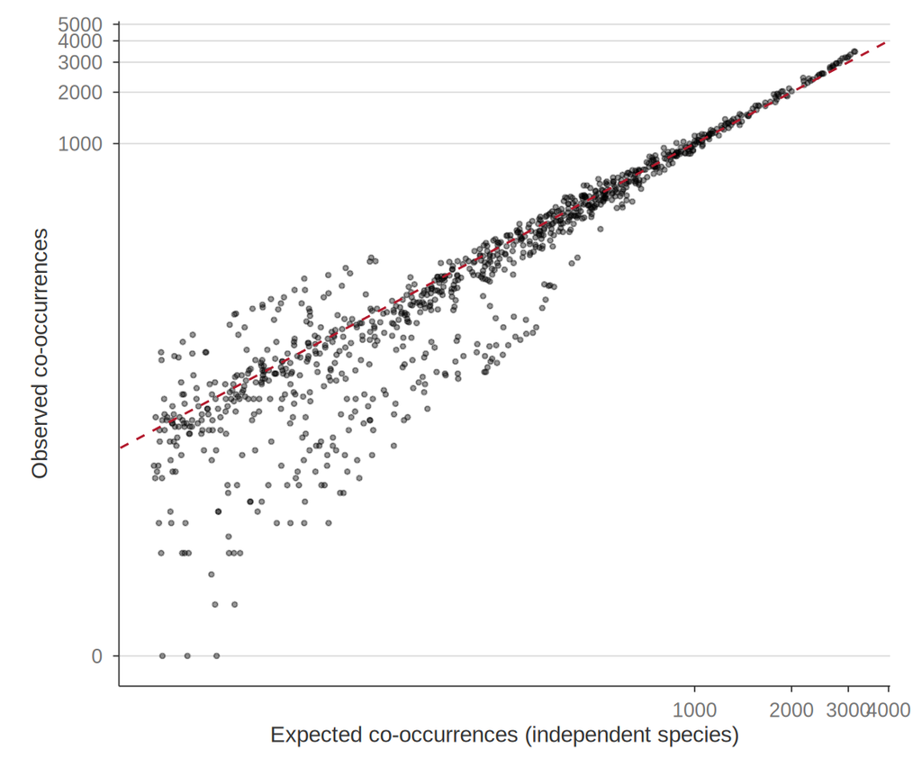

```r
probability <- tar_read(dam_presence_probability)
caught <- sapply(
  colnames(probability),
  \(s) as.numeric(rownames(probability) %in% presence$operation_id[presence$species_valid == s])
)
pair <- upper.tri(diag(ncol(probability)))
cooccurrence <- tibble(
  observed = (t(caught) %*% caught)[pair],
  expected = (t(probability) %*% probability)[pair]
) |>
  filter(expected >= 20)
cooccurrence |>
  ggplot(aes(expected, observed)) +
  geom_point(size = 0.8, alpha = 0.4) +
  geom_abline(linetype = "dashed", color = "#B2182B") +
  scale_x_continuous(transform = "log1p") +
  scale_y_continuous(transform = "log1p") +
  labs(x = "Expected co-occurrences (independent species)", y = "Observed co-occurrences")
```

**Results:** the generated webs reproduce the observed ones well. Fish richness, trophic length and diet overlap of the generated webs follow the observed values closely, visit by visit and even more site by site, and they are calibrated: the observed value falls within the central 50% and 90% of the generated webs about as often as expected. Piscivore presence is the exception, but only because almost every web has a piscivore, so there is little to predict. Species pairs co-occur about as often as expected from independent presences, with some exceptions: a few species cluster more than predicted (spined loach with lowland species), and some upland and lowland species are predicted to co-occur at a few sites where they are never caught together.

*To discuss: the species-level webs keep all the size classes of each species, so they differ from the size-class webs of D11 and D12 (correlation about 0.7-0.75 for trophic length and diet overlap).*

## Dam impacts on the generated webs

### Webs without dams

Each visit’s webs are generated a second time with the dam term of every presence model set to 0, with the same posterior draws and the same random numbers (target `dam_web_counterfactual`). The difference between the two sets of webs is the change in structure due to the species that the dams remove or add. For each posterior draw, the differences are averaged over the visits with at least one dam, overall and by number of dams; the spread over the draws gives the uncertainty.

```r
counterfactual <- tar_read(dam_web_counterfactual) |>
  summarise(
    mean = mean(difference, na.rm = TRUE),
    lower = quantile(difference, 0.025, na.rm = TRUE),
    upper = quantile(difference, 0.975, na.rm = TRUE),
    .by = c(dam_class, metric)
  ) |>
  mutate(
    metric = factor(metric, names(metric_label), metric_label),
    dam_class = factor(dam_class, c("1", "2-3", "4+", "all"), c("1 dam", "2-3 dams", "4+ dams", "all dammed visits"))
  )
```

Change in the structure of the generated webs, observed dams minus no dam, at the visits with dams (posterior mean and 95% credible interval).

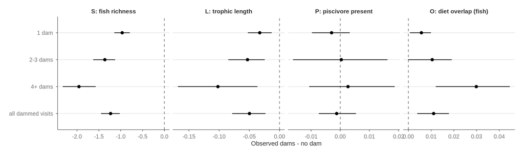

```r
counterfactual |>
  ggplot(aes(mean, dam_class)) +
  geom_vline(xintercept = 0, linetype = "dashed", color = "grey50") +
  geom_pointrange(aes(xmin = lower, xmax = upper), size = 0.3) +
  facet_wrap(~metric, nrow = 1, scales = "free_x") +
  scale_y_discrete(limits = rev) +
  labs(x = "Observed dams - no dam", y = NULL)
```

**Results:** the species that the dams remove are enough to change the webs. At the visits with dams, the generated webs without dams have about one more fish species, slightly longer food chains and slightly less diet overlap between fish species. These changes grow with the number of dams. Piscivore presence does not change: almost every web keeps a piscivore. The changes are small compared with the differences between visits.

### Dam effect fitted to generated and observed webs

The D12 models of web structure on log(1 + dams) (fish richness, Poisson; trophic length of the webs with a piscivore and diet overlap, Gaussian; same controls and random effects as the presence models; visits with at least 3 fish species) are fitted to the observed species-level webs and to 50 realisations of the generated webs, each from one posterior draw of the presence models (targets `dam_structure_observed` and `dam_structure_generated`). Each realisation uses the same parameter values at every visit, so it keeps the uncertainty of the presence models that is shared across visits (e.g. the dam effect of the eel). The posterior draws of the dam effect are pooled over the realisations: their spread combines the uncertainty of the presence models and of the structure model.

```r
structure_label <- metric_label[c("richness", "trophic_length", "fish_diet_overlap")]
structure_dam <- bind_rows(
  generated = tar_read(dam_structure_generated),
  observed = tar_read(dam_structure_observed),
  .id = "webs"
) |>
  mutate(response = factor(response, names(structure_label), structure_label))
structure_dam |>
  summarise(
    mean = mean(draw), lower = quantile(draw, 0.025), upper = quantile(draw, 0.975),
    .by = c(webs, response)
  ) |>
  arrange(response, webs) |>
  mutate(across(where(is.numeric), \(x) round(x, 3)))
```

```
# A tibble: 6 × 5
  webs      response                 mean  lower  upper
  <chr>     <fct>                   <dbl>  <dbl>  <dbl>
1 generated S: fish richness       -0.122 -0.159 -0.086
2 observed  S: fish richness       -0.114 -0.147 -0.081
3 generated L: trophic length      -0.032 -0.065  0.006
4 observed  L: trophic length      -0.019 -0.041  0.004
5 generated O: diet overlap (fish)  0.009 -0.001  0.018
6 observed  O: diet overlap (fish)  0.01   0      0.019
```

Posterior of the dam effect fitted to the observed webs and to the generated webs (pooled over realisations).

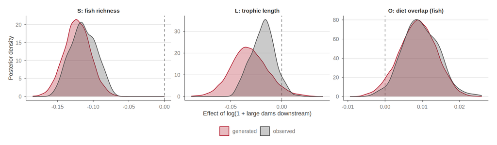

```r
structure_dam |>
  ggplot(aes(draw, fill = webs, color = webs)) +
  geom_vline(xintercept = 0, linetype = "dashed", color = "grey50") +
  geom_density(alpha = 0.3) +
  facet_wrap(~response, nrow = 1, scales = "free") +
  scale_fill_manual(values = c(observed = "grey30", generated = "#B2182B")) +
  scale_color_manual(values = c(observed = "grey30", generated = "#B2182B")) +
  labs(x = "Effect of log(1 + large dams downstream)", y = "Posterior density", fill = NULL, color = NULL)
```

**Results:** fitted to the generated webs, the model gives about the same dam effects as fitted to the observed webs: fewer species with more dams, credibly, and slightly shorter chains and slightly more diet overlap, with similar sizes, but these two are not credible (the higher diet overlap is at the edge of credibility). Since the generated webs change with the dams only through which species are present, the dam effects on the observed webs are what the loss of species predicts: there is no sign of a further effect of the dams on web structure. Pooling over realisations matters: the uncertainty of the presence models is about as large as that of the structure model.

*To discuss: the change from removing all dams (above) is larger than the fitted dam effect per unit of log(1 + dams); the structure model controls for the position and has site random effects, which may absorb part of the difference between dammed and undammed sites. The two quantities are not the same, and the comparison with the observed webs is made with the fitted model.*

## Species-level and size-class webs

The dam effect on the trophic length of the observed webs is larger at the species level than with the size-class webs of D11 and D12. Same model, same visits, fitted to the species-level and to the size-class metrics (fish richness is the same in both; targets `dam_structure_observed` and `dam_structure_size_class`).

```r
bind_rows(
  `species level` = tar_read(dam_structure_observed),
  `size classes` = tar_read(dam_structure_size_class),
  .id = "webs"
) |>
  summarise(
    mean = mean(draw), lower = quantile(draw, 0.025), upper = quantile(draw, 0.975),
    .by = c(response, webs)
  ) |>
  mutate(across(where(is.numeric), \(x) round(x, 3)))
```

```
# A tibble: 6 × 5
  response          webs            mean  lower  upper
  <chr>             <chr>          <dbl>  <dbl>  <dbl>
1 richness          species level -0.114 -0.147 -0.081
2 trophic_length    species level -0.019 -0.041  0.004
3 fish_diet_overlap species level  0.01   0      0.019
4 richness          size classes  -0.115 -0.147 -0.077
5 trophic_length    size classes  -0.004 -0.021  0.011
6 fish_diet_overlap size classes   0.009 -0.003  0.019
```

Species holding the highest trophic level of each web, by number of dams downstream (share of the visits; species at the top of at least 5% of the webs of a class), and mean trophic length of the webs topped by each species, at both levels (target `top_trophic_species`).

```r
top <- tar_read(top_trophic_species) |>
  left_join(select(visit, operation_id, dams), by = "operation_id") |>
  mutate(dam_class = cut(dams, c(-Inf, 0, 1, 3, Inf), c("0", "1", "2-3", "4+")))
top |>
  count(dam_class, top_species) |>
  mutate(share = round(n / sum(n), 2), .by = dam_class) |>
  filter(max(share) >= 0.05, .by = top_species) |>
  select(-n) |>
  tidyr::pivot_wider(names_from = dam_class, values_from = share, values_fill = 0)
```

```
# A tibble: 6 × 5
  top_species         `0`   `1` `2-3`  `4+`
  <chr>             <dbl> <dbl> <dbl> <dbl>
1 Anguilla anguilla  0.35  0.26  0.15  0.03
2 Esox lucius        0.28  0.19  0.15  0.01
3 Perca fluviatilis  0.04  0.08  0.08  0.05
4 Salmo salar        0.09  0.04  0.01  0.03
5 Salmo trutta       0.11  0.29  0.52  0.81
6 Sander lucioperca  0.05  0.04  0.02  0
```

```r
top |>
  summarise(
    webs = n(),
    trophic_length_species = round(mean(trophic_length_species), 2),
    trophic_length_size_class = round(mean(trophic_length_size_class), 2),
    .by = top_species
  ) |>
  filter(webs >= 100) |>
  arrange(desc(webs))
```

```
# A tibble: 9 × 4
  top_species         webs trophic_length_species trophic_length_size_class
  <chr>              <int>                  <dbl>                     <dbl>
1 Anguilla anguilla   1744                   4.02                      3.9
2 Esox lucius         1382                   4.35                      4.06
3 Salmo trutta        1300                   3.75                      3.69
4 Salmo salar          414                   4.18                      3.91
5 Perca fluviatilis    298                   3.88                      3.82
6 Sander lucioperca    255                   4.38                      4.08
7 Squalius cephalus    136                   3.41                      3.39
8 Ameiurus melas       108                   3.96                      3.79
9 Petromyzon marinus   101                   4.43                      3.98
```

**Results:** fish richness responds the same at both levels, and diet overlap almost the same (only less precisely with size classes). Trophic length differs: its dam effect is several times larger at the species level, although uncertain at both levels. The reason is the change of top predator: with more dams, the eel, the pike and the salmon give way to brown trout at the top of the webs. At the species level, each species carries the diet of all its size classes, so pike or pikeperch sit well above brown trout. In the size-class webs, they only reach their high trophic level when large individuals are caught, so the gap with brown trout is about half as large, and the dam effect smaller. Species-level trophic length measures which species are present; size-class trophic length also depends on the sizes caught.

## Dam weighting

Does every dam count the same? The $k$-th dam between the site and the sea is weighted by $w^{k-1}$: $w = 1$ gives the number of dams (used above), $w = 0$ only the first dam, $0 < w < 1$ a saturating count and $w > 1$ an accelerating one; $\log(1 + \text{weighted dams})$ replaces $\log(1 + D_i)$. The models of the observed species-level structure (target `dam_weight_structure`) and the presence models of the 48 species (coarser grid of $w$; target `dam_weight_presence`) are refitted for each $w$ and compared by their log marginal likelihood. WAIC is not used here: it is unstable for the rare species (differences of thousands between neighbouring weights).

```r
weight_structure <- tar_read(dam_weight_structure) |>
  mutate(delta = mlik - mlik[weight == 1], .by = response) |>
  mutate(panel = metric_label[response])
weight_presence <- tar_read(dam_weight_presence) |>
  mutate(delta = mlik - mlik[weight == 1], .by = species)
weight_presence |>
  slice_max(mlik, n = 1, by = species) |>
  count(best_weight = weight, name = "species")
```

```
# A tibble: 5 × 2
  best_weight species
        <dbl>   <int>
1         0        18
2         0.5      13
3         1         6
4         1.5       3
5         2         8
```

Log marginal likelihood of each weighting relative to the number of dams ($w = 1$): web structure (observed species-level webs) and the presence models summed over the 48 species (grey band: within 2).

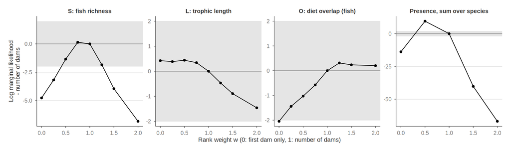

```r
bind_rows(
  weight_structure |> select(panel, weight, delta),
  weight_presence |>
    summarise(delta = sum(delta), .by = weight) |>
    mutate(panel = "Presence, sum over species")
) |>
  mutate(panel = factor(panel, c(metric_label[c("richness", "trophic_length", "fish_diet_overlap")], "Presence, sum over species"))) |>
  ggplot(aes(weight, delta)) +
  annotate("rect", xmin = -Inf, xmax = Inf, ymin = -2, ymax = 2, fill = "grey90") +
  geom_hline(yintercept = 0, color = "grey60") +
  geom_line() +
  geom_point() +
  facet_wrap(~panel, nrow = 1, scales = "free_y") +
  labs(x = "Rank weight w (0: first dam only, 1: number of dams)", y = "Log marginal likelihood\n- number of dams")
```

Species whose presence model fits clearly better (by more than 2) with another weighting than the number of dams.

```r
weight_presence |>
  slice_max(mlik, n = 1, by = species) |>
  filter(delta > 2) |>
  transmute(species, best_weight = weight, delta = round(delta, 1)) |>
  arrange(desc(delta))
```

```
# A tibble: 5 × 3
  species             best_weight delta
  <chr>                     <dbl> <dbl>
1 Pseudorasbora parva         0.5   3.9
2 Blicca bjoerkna             0     3.6
3 Barbus meridionalis         0     3.1
4 Rhodeus amarus              0     2.2
5 Pachychilon pictum          0.5   2
```

**Results:** counting every dam the same fits as well as any other weighting. For fish richness, the number of dams fits best, and counting only the first dam fits clearly worse. For trophic length and diet overlap, all weightings fit about equally: the data cannot tell how the dams add up for the web structure. Summed over the 48 species, a saturating count (the first dams matter more) fits better than the number of dams, counting only the first dam worse, and an accelerating count clearly worse; most species show no clear preference. The eel needs the number of dams: counting only the first dam fits clearly worse. A few species fit better with the first dam only (white bream, Mediterranean barbel, bitterling), and the topmouth gudgeon and the Albanian roach with a saturating count.

## Dam removal

How much would removing each dam change the species and the webs upstream? Removing any one of the dams downstream of a site lowers its number of dams by one, so the webs of each visit are generated once more with one dam fewer, with the same draws and random numbers (target `dam_web_one_less`). The importance of a dam is the change at the sampled sites upstream of it (mean over the visits of each site), summed over these sites, for each posterior draw (target `dam_removal`). The gain in fish richness of a dam is thus the expected number of species found in addition, summed over the sites upstream.

```r
removal <- tar_read(dam_removal)
dam_info <- tar_read(large_dam) |>
  sf::st_drop_geometry() |>
  select(roe_code, name, river, kind, drop_height_min, altitude)
dams_below <- tar_read(dam_dam) |>
  filter(position == "upstream") |>
  count(roe_code = operation_id, name = "dams_below")
importance <- removal$web |>
  summarise(
    sites = first(sites),
    lower = quantile(total, 0.025), upper = quantile(total, 0.975),
    total = mean(total), per_site = mean(per_site),
    .by = c(roe_code, metric)
  ) |>
  left_join(dam_info, by = "roe_code") |>
  left_join(dams_below, by = "roe_code") |>
  mutate(
    rank = coalesce(dams_below, 0L) + 1,
    rank_class = cut(rank, c(0, 1, 2, 4, Inf), c("1st", "2nd", "3rd-4th", "5th+"))
  )
richness_gain <- filter(importance, metric == "richness")
c(
  dams = nrow(richness_gain),
  credible_gain = sum(richness_gain$lower > 0),
  share_top_20 = sum(sort(richness_gain$total, decreasing = TRUE)[1:20]) / sum(richness_gain$total)
)
```

```
         dams credible_gain  share_top_20
  191.0000000    47.0000000     0.7174842
```

The 15 dams whose removal would add the most fish species (summed over the sites upstream, posterior mean and 95% credible interval), with the change in trophic length summed over the same sites.

```r
richness_gain |>
  arrange(desc(total)) |>
  head(15) |>
  left_join(
    importance |> filter(metric == "trophic_length") |> select(roe_code, trophic_length = total),
    by = "roe_code"
  ) |>
  transmute(
    roe_code, name = stringr::str_trunc(name, 30), river = stringr::str_trunc(river, 22),
    kind, height = paste0(">= ", drop_height_min, " m"), rank, sites,
    richness = sprintf("%.1f (%.1f, %.1f)", total, lower, upper),
    trophic_length = round(trophic_length, 2)
  ) |>
  knitr::kable()
```

| roe_code | name | river | kind | height | rank | sites | richness | trophic_length |
| --- | --- | --- | --- | --- | --- | --- | --- | --- |
| ROE52354 | Barrage usine de Poses | fleuve la seine | dam | >= 5 m | 1 | 106 | 82.1 (60.3, 104.5) | 1.81 |
| ROE12590 | Barrage de Malause | fleuve la garonne | dam | >= 5 m | 1 | 116 | 68.3 (49.8, 88.5) | 2.32 |
| ROE30284 | Pont barrage de VICHY | rivière l’allier | weir | >= 5 m | 1 | 78 | 63.1 (45.8, 83.9) | 2.66 |
| ROE19881 | usine électrique de CHATELL… | rivière la vienne | weir | >= 5 m | 1 | 58 | 42.3 (32.4, 54.7) | 0.97 |
| ROE66029 | Barrage et usine de Tuilières | rivière la dordogne | dam | >= 5 m | 1 | 54 | 41.2 (27.4, 57.3) | 1.52 |
| ROE45229 | barrage de Villerest | fleuve la loire | dam | >= 10 m | 1 | 50 | 39.3 (27.1, 51.4) | 1.43 |
| ROE43835 | Barrage EDF Le Temple | rivière le lot | dam | >= 10 m | 1 | 29 | 13.9 (7.2, 22.2) | 0.49 |
| ROE5543 | Barrage de Saint Fraimbault | rivière la mayenne | dam | >= 10 m | 1 | 12 | 13.3 (7.2, 19.8) | 0.47 |
| ROE2676 | CHAUSSEE DU BAZACLE | fleuve la garonne | weir | >= 5 m | 2 | 22 | 9.6 (4.9, 16.0) | 0.25 |
| ROE10691 | Barrage de l’Abattoir | rivière le cher | weir | >= 5 m | 1 | 7 | 8.2 (3.6, 13.3) | 0.23 |
| ROE26980 | Barrage de Grangent | fleuve la loire | dam | >= 10 m | 2 | 21 | 7.1 (2.6, 12.0) | 0.30 |
| ROE13116 | Barrage EDF de Luzech | rivière le lot | dam | >= 10 m | 2 | 22 | 6.9 (2.3, 12.0) | 0.25 |
| ROE61444 |  | rivière l’aisne | weir | >= 5 m | 2 | 21 | 6.9 (2.8, 12.0) | 0.08 |
| ROE29073 | Barrage de Chardes | rivière la vienne | dam | >= 10 m | 2 | 31 | 6.8 (2.5, 12.3) | 0.21 |
| ROE123463 | Usine hydroélectrique de Sa… |  | weir | >= 5 m | 1 | 7 | 6.5 (2.3, 12.3) | 0.23 |

Richness gain of each dam against the number of sampled sites upstream (left) and per site against its rank from the sea (right).

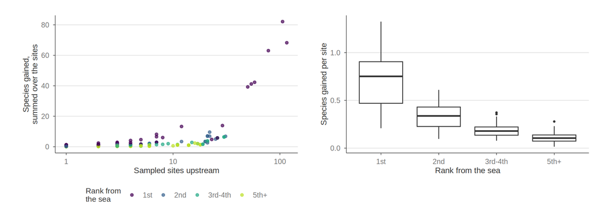

```r
patchwork::wrap_plots(
  richness_gain |>
    ggplot(aes(sites, total, color = rank_class)) +
    geom_point(alpha = 0.7) +
    scale_x_log10() +
    scale_color_viridis_d(end = 0.9) +
    labs(x = "Sampled sites upstream", y = "Species gained,\nsummed over the sites", color = "Rank from\nthe sea"),
  richness_gain |>
    ggplot(aes(rank_class, per_site)) +
    geom_boxplot(outlier.size = 0.8) +
    labs(x = "Rank from the sea", y = "Species gained per site")
)
```

Species that would gain the most (expected number of sites upstream where each is found in addition, summed over the removals of single dams).

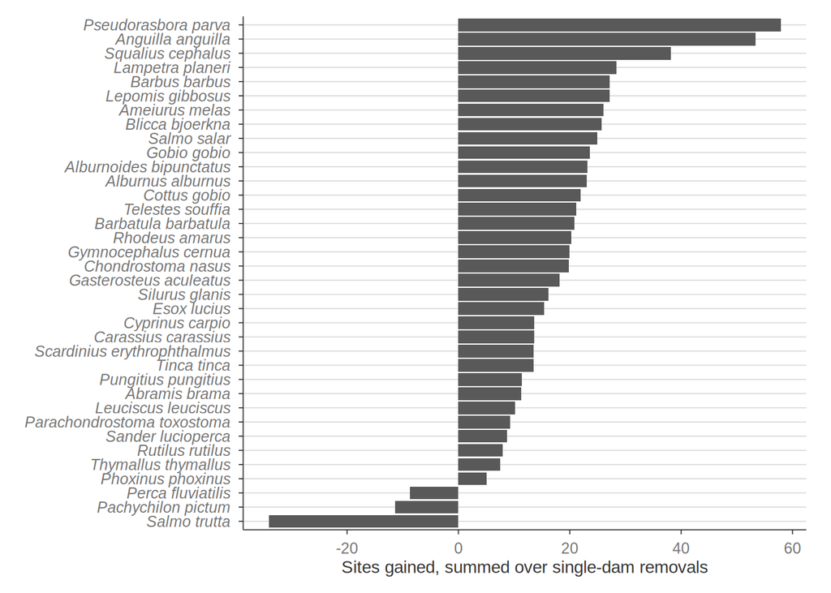

```r
removal$species |>
  summarise(sites_gained = sum(sites_gained), .by = species) |>
  filter(abs(sites_gained) >= 5) |>
  mutate(species = reorder(species, sites_gained)) |>
  ggplot(aes(sites_gained, species)) +
  geom_col() +
  labs(x = "Sites gained, summed over single-dam removals", y = NULL) +
  theme(axis.text.y = element_text(face = "italic"))
```

**Results:** most dams matter little for the sampled sites: about a quarter of the 191 dams with sites upstream would credibly add species if removed, and 20 dams account for most of the total gain. The most important dams are those with many sampled sites upstream and few other dams downstream: the first dam from the sea on large rivers, such as Poses on the Seine, Malause on the Garonne, the weir of Vichy on the Allier, Châtellerault on the Vienne or Tuilières on the Dordogne. Per site, the gain falls quickly with the rank of the dam from the sea; this follows partly from the model itself, in which a dam adds less where there are already many. The species that would gain most are the eel and lowland species, native or not (topmouth gudgeon, chub, pumpkinseed, barbel, black bullhead, white bream), and the brook lamprey; brown trout and the Albanian roach would lose sites.

*To discuss: importance is measured at sampled sites only, so it depends on where sampling took place, not on the length of river upstream.*

### Dam importance over the river network

The importance above depends on where sampling took place. Here, presence is predicted on every reach of the river network instead (RHT reaches of the four districts, placed on the AMOBIO network by their midpoint, within the range of width, altitude and distance to the mouth of the visits; target `network_reach`), for a typical site and year (reference protocol, median fished surface), with the observed number of dams downstream and with one dam fewer. The dam weighting is averaged over the rank weights (Bayesian model averaging): each species is refitted for each weight (target `dam_presence_weight_sample`), and each posterior draw comes from one weight, drawn with probabilities from the log marginal likelihoods. The importance of a dam is the change in presence summed over the species and over the reaches upstream, weighted by their length: species x km gained (target `dam_removal_network`).

```r
network <- tar_read(dam_removal_network)
traits <- tar_read(dam_traits)
network_gain <- network$richness |>
  summarise(
    lower = quantile(gain, 0.025), upper = quantile(gain, 0.975), gain = mean(gain),
    .by = roe_code
  ) |>
  left_join(network$upstream_km, by = "roe_code") |>
  mutate(per_km = gain / km) |>
  left_join(traits, by = "roe_code")
c(
  reaches = nrow(tar_read(network_reach)), dams = nrow(network_gain),
  credible_gain = sum(network_gain$lower > 0),
  share_top_20 = sum(sort(network_gain$gain, decreasing = TRUE)[1:20]) / sum(network_gain$gain)
)
```

```
      reaches          dams credible_gain  share_top_20
 4.718400e+04  4.640000e+02  4.510000e+02  7.023982e-01
```

```r
network$model_weight |>
  summarise(mean_probability = round(mean(probability), 2), .by = weight)
```

```
# A tibble: 5 × 2
  weight mean_probability
   <dbl>            <dbl>
1    0               0.23
2    0.5             0.28
3    1               0.21
4    1.5             0.16
5    2               0.13
```

The 15 dams whose removal would add the most species x km (posterior mean and 95% credible interval), with the river length upstream and the gain per km.

```r
network_gain |>
  arrange(desc(gain)) |>
  head(15) |>
  transmute(
    roe_code, name = stringr::str_trunc(name, 30), river = stringr::str_trunc(river, 22),
    kind, rank, dist_mouth_km = round(dist_mouth_km), upstream_km = round(km),
    gain = sprintf("%.0f (%.0f, %.0f)", gain, lower, upper), per_km = round(per_km, 2)
  ) |>
  knitr::kable()
```

| roe_code | name | river | kind | rank | dist_mouth_km | upstream_km | gain | per_km |
| --- | --- | --- | --- | --- | --- | --- | --- | --- |
| ROE12590 | Barrage de Malause | fleuve la garonne | dam | 1 | 226 | 9058 | 4708 (3795, 5626) | 0.52 |
| ROE52354 | Barrage usine de Poses | fleuve la seine | dam | 1 | 164 | 6360 | 4270 (3273, 5303) | 0.67 |
| ROE66029 | Barrage et usine de Tuilières | rivière la dordogne | dam | 1 | 148 | 5870 | 3319 (2670, 3981) | 0.57 |
| ROE30284 | Pont barrage de VICHY | rivière l’allier | weir | 1 | 661 | 2987 | 3098 (2557, 3663) | 1.04 |
| ROE19881 | usine électrique de CHATELL… | rivière la vienne | weir | 1 | 273 | 4153 | 2541 (2138, 2943) | 0.61 |
| ROE123463 | Usine hydroélectrique de Sa… |  | weir | 1 | 140 | 1552 | 1555 (1220, 1882) | 1.00 |
| ROE45229 | barrage de Villerest | fleuve la loire | dam | 1 | 736 | 1617 | 1441 (1194, 1718) | 0.89 |
| ROE43835 | Barrage EDF Le Temple | rivière le lot | dam | 1 | 175 | 3803 | 1227 (975, 1460) | 0.32 |
| ROE10691 | Barrage de l’Abattoir | rivière le cher | weir | 1 | 382 | 834 | 1141 (943, 1349) | 1.37 |
| ROE5543 | Barrage de Saint Fraimbault | rivière la mayenne | dam | 1 | 278 | 915 | 1107 (919, 1300) | 1.21 |
| ROE13116 | Barrage EDF de Luzech | rivière le lot | dam | 2 | 283 | 3224 | 547 (395, 711) | 0.17 |
| ROE2676 | CHAUSSEE DU BAZACLE | fleuve la garonne | weir | 2 | 311 | 1657 | 432 (323, 553) | 0.26 |
| ROE25381 | barrage du sablier | rivière la dordogne | dam | 2 | 340 | 1990 | 343 (245, 461) | 0.17 |
| ROE44851 | Seuil des centrales hydroél… | gave de pau | dam | 1 | 66 | 2329 | 336 (231, 454) | 0.14 |
| ROE61444 |  | rivière l’aisne | weir | 2 | 552 | 1347 | 309 (136, 445) | 0.23 |

### What do the most important dams have in common?

Spearman correlation of the total gain and of the gain per km of river upstream with the position and characteristics of the dams (target `dam_traits`): river length upstream (within the range of the visits), share of the river length of its catchment upstream of the dam, drained area and Strahler order at the dam, rank from the sea, number of large dams upstream, distance to the mouth, altitude and drop height class.

```r
network_gain |>
  transmute(
    gain, per_km, upstream_km = km, upstream_share, drained_area, strahler,
    rank, dams_upstream, dist_mouth_km, altitude, height = drop_height_min
  ) |>
  cor(method = "spearman", use = "pairwise") |>
  (\(x) x[c("gain", "per_km"), -(1:2)])() |>
  round(2)
```

```
       upstream_km upstream_share drained_area strahler  rank dams_upstream
gain          0.84           0.71         0.69     0.65 -0.32          0.53
per_km       -0.22          -0.07        -0.26    -0.24 -0.93         -0.30
       dist_mouth_km altitude height
gain           -0.20    -0.39   0.12
per_km         -0.28    -0.59  -0.13
```

Total gain against the river length upstream (left) and gain per km against the rank from the sea (middle) and the altitude of the dam (right).

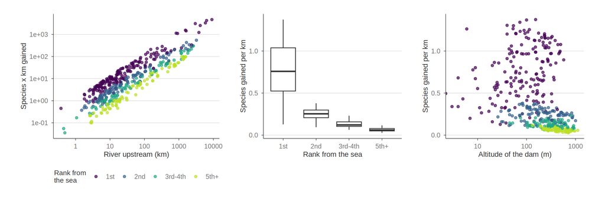

```r
network_gain <- network_gain |>
  mutate(rank_class = cut(rank, c(0, 1, 2, 4, Inf), c("1st", "2nd", "3rd-4th", "5th+")))
patchwork::wrap_plots(
  ggplot(network_gain, aes(km, gain, color = rank_class)) +
    geom_point(alpha = 0.7) +
    scale_x_log10() +
    scale_y_log10() +
    scale_color_viridis_d(end = 0.9) +
    labs(x = "River upstream (km)", y = "Species x km gained", color = "Rank from\nthe sea"),
  ggplot(network_gain, aes(rank_class, per_km)) +
    geom_boxplot(outlier.size = 0.8) +
    labs(x = "Rank from the sea", y = "Species gained per km"),
  ggplot(network_gain, aes(altitude, per_km, color = rank_class)) +
    geom_point(alpha = 0.7) +
    scale_x_log10() +
    scale_color_viridis_d(end = 0.9, guide = "none") +
    labs(x = "Altitude of the dam (m)", y = "Species gained per km"),
  widths = c(1.2, 1, 1)
)
```

**Results:** predicted over the whole network, the ranking is close to the one from the sampled sites, but it covers more dams and no longer depends on where sampling took place. Removing almost any dam would credibly bring back some species upstream, but a few dams dominate: 20 dams account for more than two thirds of the total gain. They are the first dams from the sea on large rivers: Malause on the Garonne, Poses on the Seine, Tuilières on the Dordogne, the weir of Vichy on the Allier, Châtellerault on the Vienne, Villerest on the Loire, Le Temple on the Lot. Two things make a dam important. First, how much river it cuts off: the total gain follows the river length upstream, the drained area and the share of its catchment above it. Second, how many dams already stand downstream: the gain per km of river falls steeply with the rank of the dam from the sea, and it is also larger for dams at low altitude, where the reaches upstream hold more of the species that dams remove. The drop height plays almost no role. The averaging gives slightly more weight to the weightings in which the first dams count most, so the data do not contradict this rank effect, but it remains largely set by the shape of the model, in which a dam adds less where there are already many.

*To discuss: the importance only covers the reaches within the range of the visits, and assumes that all dams act the same (no effect of height, type or fish pass in the presence models).*

### Dam importance and river connectivity

The dendritic connectivity index (DCI, Cote et al. 2009, Landscape Ecology) is the usual way to score river fragmentation. It has two forms, computed here on the same reaches (target `dam_connectivity`):

- diadromous (DCI_d): the share of river length reachable from the sea. A reach with D dams downstream counts its length times p^D, with p the passability of a dam, so removing one of the dams adds the length of each reach upstream times p^(D-1) (1-p)
- potamodromous (DCI_p): the chance that two points of the river are connected. Removing an impassable dam joins the free segment above it to the one holding it, adding twice the product of their lengths

Both are usually divided by the river length of the catchment (and its square for DCI_p), to score each catchment from 0 to 1; both forms are shown. Spearman correlation of the species x km gained with the gain in each index, and number of dams in common in the top 20.

```r
connectivity <- network_gain |>
  select(roe_code, gain, km) |>
  inner_join(tar_read(dam_connectivity), by = "roe_code") |>
  mutate(
    dci_d_0.5_catchment = dci_d_0.5 / catchment_km,
    dci_p_catchment = dci_p / catchment_km^2
  )
index <- c(
  km = "River upstream (km)",
  dci_d_0.25 = "DCI_d, p = 0.25", dci_d_0.5 = "DCI_d, p = 0.5", dci_d_0.75 = "DCI_d, p = 0.75",
  dci_d_0.5_catchment = "DCI_d, p = 0.5, per catchment",
  dci_p = "DCI_p", dci_p_catchment = "DCI_p, per catchment"
)
top_20 <- function(score) connectivity$roe_code[order(score, decreasing = TRUE)[1:20]]
tibble(
  index = index,
  spearman = sapply(names(index), \(v) cor(connectivity$gain, connectivity[[v]], method = "spearman")),
  top_20_shared = sapply(names(index), \(v) length(intersect(top_20(connectivity$gain), top_20(connectivity[[v]]))))
) |>
  mutate(spearman = round(spearman, 2)) |>
  knitr::kable()
```

| index | spearman | top_20_shared |
| --- | --- | --- |
| River upstream (km) | 0.84 | 13 |
| DCI_d, p = 0.25 | 0.76 | 14 |
| DCI_d, p = 0.5 | 0.91 | 14 |
| DCI_d, p = 0.75 | 0.96 | 17 |
| DCI_d, p = 0.5, per catchment | 0.73 | 1 |
| DCI_p | 0.58 | 13 |
| DCI_p, per catchment | 0.49 | 1 |

Species x km gained against the gain in DCI_d with p = 0.75 (left) and in DCI_p (right).

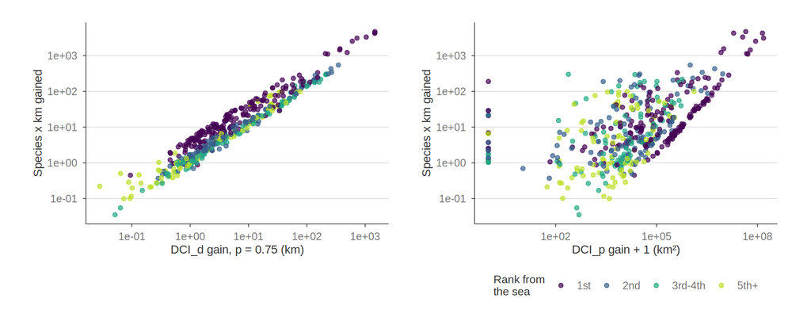

```r
connectivity <- connectivity |>
  left_join(select(network_gain, roe_code, rank_class), by = "roe_code")
patchwork::wrap_plots(
  ggplot(connectivity, aes(dci_d_0.75, gain, color = rank_class)) +
    geom_point(alpha = 0.7) +
    scale_x_log10() +
    scale_y_log10() +
    scale_color_viridis_d(end = 0.9, guide = "none") +
    labs(x = "DCI_d gain, p = 0.75 (km)", y = "Species x km gained"),
  ggplot(connectivity, aes(dci_p + 1, gain, color = rank_class)) +
    geom_point(alpha = 0.7) +
    scale_x_log10() +
    scale_y_log10() +
    scale_color_viridis_d(end = 0.9) +
    labs(x = "DCI_p gain + 1 (km²)", y = "Species x km gained", color = "Rank from\nthe sea")
)
```

**Results:** the dam ranking is almost the same as the one given by the diadromous connectivity index with a passability of about 0.75: the two share 17 of their top 20 dams. This is expected from the form of the models: the gain of a dam is a sum over the river upstream, weighted by length, of a change that shrinks with the number of dams already downstream, which is how the diadromous index is built. The models fix how fast it shrinks (about as fast as a passability of 0.75) and weight each km by the species it could hold, but this second part changes the ranking little. The potamodromous index ranks dams differently, favouring dams that split two long free segments wherever they stand. Dividing by the catchment length gives another ranking again, led by small coastal rivers: it scores the improvement within a catchment, not the absolute gain.

*To discuss: the presence models only count the dams downstream of a site, so they cannot capture fragmentation away from the sea, which is what the potamodromous index measures; the weak match with it follows from the model and is not a finding. Adding the length of the free segment holding each site to the presence models of five species (barbel, nase, chub, brown trout, eel) showed no effect beyond the dams downstream, so the ranking was kept diadromous.*